# Lab 8, Part 1: Point Pattern Analysis

Shuying Yu

2/24/2022

```r
knitr::opts_chunk$set(echo = TRUE, warning = FALSE, message=FALSE)

#Attach libraries
library(spatstat)
library(maptools)
# library(sp)
library(raster) ### BEFORE tidyverse! b/c select() for tidyverse is preferred
library(tidyverse)
library(here)
library(sf)
library(tmap)
```

# Point Pattern Analysis

## Plot points on coordinate system

This is an example of point pattern analysis with a density plot, and the G- & L- function (distance methods) to compare our observed points with simulated complete spatial randomness.

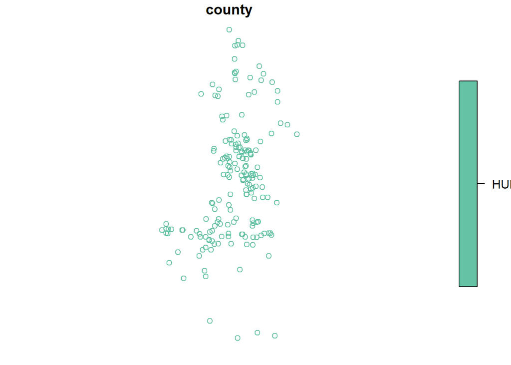

```r
# Read in the tree vole data
#dsn = data source name, folder with data
voles <- read_sf(dsn = here("redtreevoledata"),

                 #inside dsn, want layer called ds033
                 layer = "ds033") %>%
  janitor::clean_names() %>%
  select(county) %>% # Only select the county attribute
  filter(county == "HUM") %>% # Only keep observations in Humboldt County

  #Custom coordinate system if see st_crs has epsg of code number 32610
  st_transform(crs = 32610) # Update CRS to UTM zone 10 N, coordinate ref system for the U.S.

# Plot it (exploratory)
plot(voles)
```

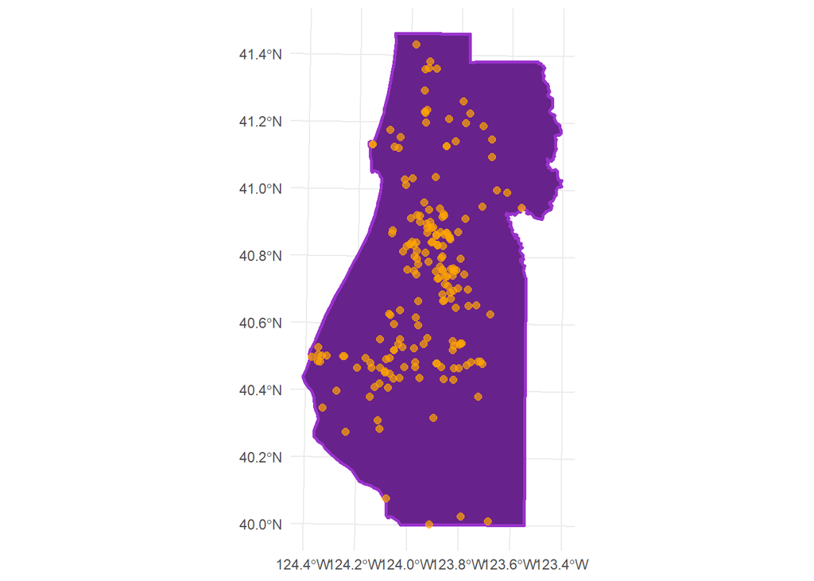

```r
# Get Humboldt County outline
humboldt <- read_sf(dsn = here("redtreevoledata"),
                    layer = "california_county_shape_file") %>%
  janitor::clean_names() %>%
  filter(name == "Humboldt") %>% # Isolate Humboldt County
  select(name) %>% # Only keep one attribute (name) to simplify

  #Has no coordinate ref system, so assign it manually
  st_set_crs(4326) %>%

  #This transforms one coordiante system to another
  #Convert to meters of UTM 10
  st_transform(crs = 32610)



# plot them together
ggplot() +
  geom_sf(data = humboldt,
          color = "darkorchid",
          fill = "darkorchid4",

          #Size of border of polygons
          size = 1) +

  geom_sf(data = voles,
          color = "orange",
          alpha = 0.7,
          size = 2) +
  theme_minimal()
```

Do they look more clustered or random points?

These need to be combined into spatial point pattern data (points + window combo), and for point pattern analysis this **requires a 2D projection** (in this case, UTM), which is why we set the CRS to 32610 above. This looks quite a bit different from what we’ve done so far - it uses functions in `spatstat` to create point patterns that play nicely with other functions for data viz & point pattern analysis.

Convert from simple features to older R spatial package in order to move forward with spatial stats for point pattern estimate. `sp` is R’s old spatial package, and `spatstat` works well with this older package.

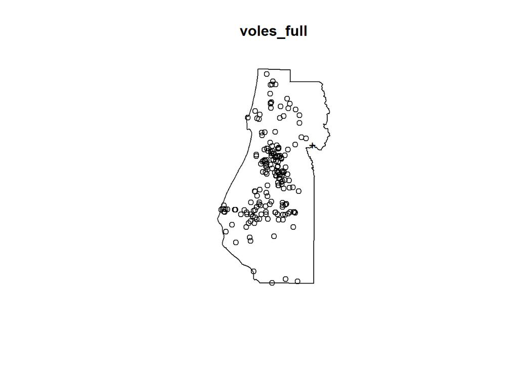

```r
voles_sp  <- as(voles,"Spatial") # Convert to object 'Spatial'
voles_ppp <- as(voles_sp, "ppp") # Convert to spatial point pattern

humboldt_sp  <- as(humboldt, "Spatial") # Convert to object 'Spatial'

#Comes from spatial stats package: ppp and owin
humboldt_win <- as(humboldt_sp, "owin") # Convert to spatial point pattern from spatstat

# Combine as a point pattern object (points + window):
voles_full <- ppp(voles_ppp$x, voles_ppp$y, window = humboldt_win)

plot(voles_full) # Illegal point (outside window) shows up as the plus sign
```

The point with plus sign is outside of the county line according to the Humboldt county lines here.

## Make a kernel density plot:

### Density

Run to see vole “hotspots” by kernel density, then see what happens when you change sigma here!

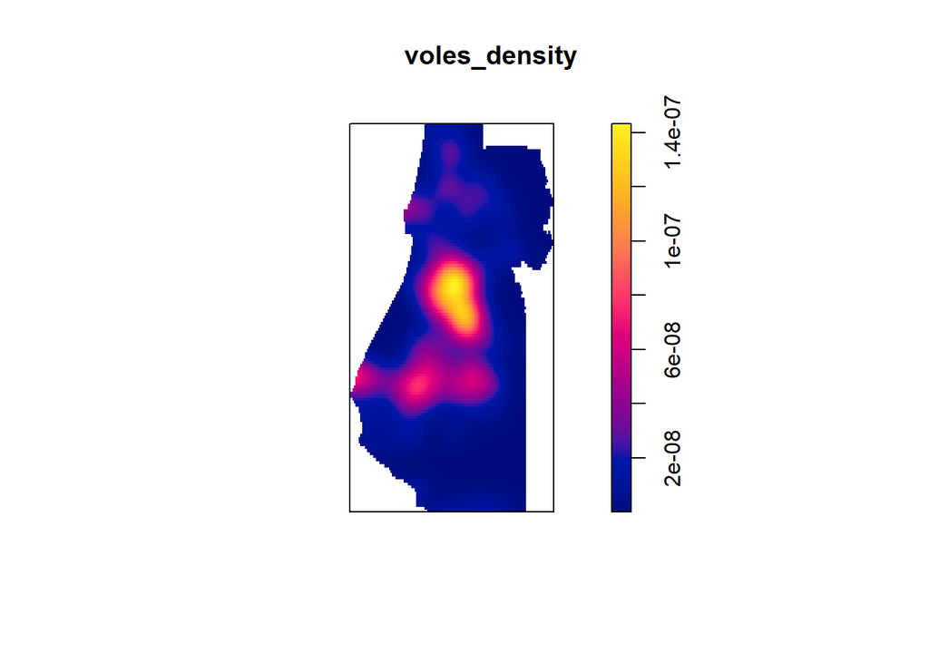

```r
#Take points and say x,y position spatial points have a probability distribution around it
#Sigma=1, units of reference sys is in meters, create normal curve where curve is and give std of 1 meter around that
voles_density <- density(voles_full, sigma = 5000)

plot(voles_density)
```

Pretty clear that there are “hotspots” where voles are observed - both in the originally plotted data and in the density plot. How can we compare this to complete spatial randomness?

```r
# Can you start viewing this in tmap? Yes, rasterize it:

#Rasters are grids, show resolution, with values across pixels
#No crs information, or it gets lost in the transformation, so reassign it back
vole_raster <- raster(voles_density)
crs(vole_raster) <- crs(voles)

# Then plot:
tmap_mode("view") #this is how we make it interactive

tm_shape(vole_raster) +
  tm_raster(midpoint = NA,
            palette = "Reds",
            legend.show = FALSE)
```

[interactive chart not shown]

## Nearest neighbor (G-function)

In last week’s lecture, we learned about distance methods to compare our point pattern to a scenario of complete spatial randomness. Here, we’ll use both the G- and L-functions (L function is the K-function, standardized…interpretation is the same) to compare our observed point pattern to a simulated CSR scenario, to help us determine if it is *more clustered* or *more uniform* than CSR.

What is going on in this code?

- `r`: a sequence of distances (in the spatial units of the data) over which we’ll calculate the proportion of points with nearest neighbor within that range
- `gfunction`: This uses the `envelope()` function within which we run simulations for CSR, *and* calculate the G-function value at distances *r* for each simulation. So this will calculate the G-function for *our* actual data, and also for simulations of CSR if we had the same number of observations in the window but they were independent. The `nsim = 100` here means there will be 100 simulations of CSR. The `nrank = 2` means that the second highest and second lowest values from simulations are shown as the “hi” and “lo” value envelopes, with the “theo” being the “theoretical value of the summary function under CSR (Complete Spatial Randomness, a uniform Poisson point process) if the simulations were generated according to CSR.” So we’re really comparing our “observed” data to the “theoretical CSR” here, and those “hi” and “lo” envelope bounds give us an idea of spread for the simulations.

```r
r_vec <- seq(0, 10000, by = 100) # Make a sequence of distances over which you'll calculate G(r)

gfunction <- envelope(voles_full, fun = Gest, r = r_vec, nsim = 100, nrank = 2) # Calculate the actual and theoretical G(r) values, using 100 simulations of CRS for the "theoretical" outcome
```

```
## Generating 100 simulations of CSR  ...
## 1, 2, 3, 4, 5, 6, 7, 8, 9, 10, 11, 12, 13, 14, 15, 16, 17, 18, 19, 20, 21, 22, 23, 24, 25, 26, 27, 28, 29, 30, 31, 32, 33, 34, 35, 36, 37, 38, 39, 40,
## 41, 42, 43, 44, 45, 46, 47, 48, 49, 50, 51, 52, 53, 54, 55, 56, 57, 58, 59, 60, 61, 62, 63, 64, 65, 66, 67, 68, 69, 70, 71, 72, 73, 74, 75, 76, 77, 78, 79, 80,
## 81, 82, 83, 84, 85, 86, 87, 88, 89, 90, 91, 92, 93, 94, 95, 96, 97, 98, 99,  100.
##
## Done.
```

```r
gfunction # << Check the output of gfunction, then...
```

```
## Pointwise critical envelopes for G(r)
## and observed value for 'voles_full'
## Edge correction: "km"
## Obtained from 100 simulations of CSR
## Alternative: two.sided
## Significance level of pointwise Monte Carlo test: 4/101 = 0.0396
## .....................................................................
##      Math.label     Description
## r    r              distance argument r
## obs  hat(G)[obs](r) observed value of G(r) for data pattern
## theo G[theo](r)     theoretical value of G(r) for CSR
## lo   hat(G)[lo](r)  lower pointwise envelope of G(r) from simulations
## hi   hat(G)[hi](r)  upper pointwise envelope of G(r) from simulations
## .....................................................................
## Default plot formula:  .~r
## where "." stands for 'obs', 'theo', 'hi', 'lo'
## Columns 'lo' and 'hi' will be plotted as shading (by default)
## Recommended range of argument r: [0, 4400]
## Available range of argument r: [0, 10000]
```

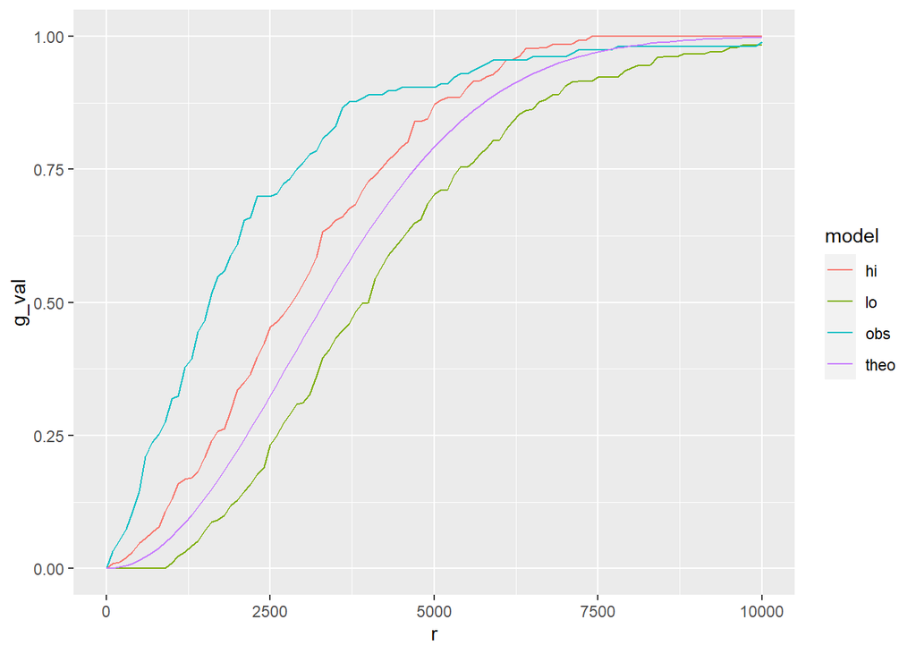

```r
# Gather this to plot series in ggplot:
gfunction_long <- gfunction %>%
  as.data.frame() %>%
  pivot_longer(cols = obs:hi, names_to = "model", values_to = "g_val")

# Then make a graph in ggplot:
ggplot(data = gfunction_long, aes(x = r, y = g_val, group = model)) +
  geom_line(aes(color = model))
```

Purple for what complete spatial random looks like, green and red are low/high end of what is considered spatial randomness. Teal is the observed spatial randomnesS.

This tells us that the voles data is more clustered, the teal line is steeper as it goes up

## K function, or standardized L function

```r
#Let sequence go farther, create a new sequence
r_vec2 <- seq(0, 100000, by = 5000)

#Envelope function from spatial stats
lfunction <- envelope(voles_full, fun = Lest, r = r_vec2, nsim = 10, rank = 2, global = TRUE)
```

```
## Generating 10 simulations of CSR  ...
## 1, 2, 3, 4, 5, 6, 7, 8, 9,  10.
##
## Done.
```

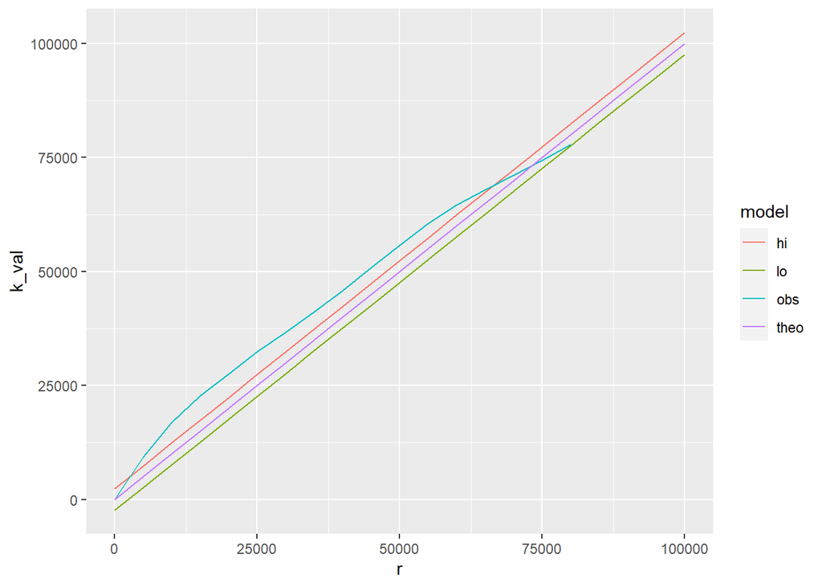

```r
# Gather this to plot series in ggplot:
lfunction_long <- lfunction %>%
  as.data.frame() %>%
  pivot_longer(cols = obs:hi, names_to = "model", values_to = "k_val")

ggplot(data = lfunction_long, aes(x = r, y = k_val, group = model)) +
  geom_line(aes(color = model))
```

Around each point, create expanding window. As we get farther, how many other points are within the radius of circle? Only 10 because it will be slower than 100. Within 10k meters, able to capture all nearest neighbors in K function. Make window bigger in rvec to account for comparing voles from one part of county to another

Plot shows fairly straight lines, we normalize area rather than just radius. Interpretation is similar. Observed data shows that there is higher proportion closer together that goes up: highest than highest expected values for L function based on complete spatial randomness, we find that there are clusters rather than randomness.

We again see that at lower distances, our data overall has a higher density of nearest neighbors compared to a simulated CSR scenario. Again, evidence of clustering.